# Risk Factor Analysis

## Outcome Variable

**Outcome Variable:** stunted

## Predictor Variables

**Intervention Variable:** brthmon

**Adjustment Set:**

unadjusted

## Stratifying Variables

The analysis was stratified on these variable(s):

- agecat
- studyid
- country

## Data Summary

| agecat | studyid | country | brthmon | stunted | n_cell | n |
| --- | --- | --- | --- | --- | --- | --- |
| Birth | ki0047075b-MAL-ED | BANGLADESH | 1 | 0 | 16 | 231 |
| Birth | ki0047075b-MAL-ED | BANGLADESH | 1 | 1 | 4 | 231 |
| Birth | ki0047075b-MAL-ED | BANGLADESH | 2 | 0 | 18 | 231 |
| Birth | ki0047075b-MAL-ED | BANGLADESH | 2 | 1 | 5 | 231 |
| Birth | ki0047075b-MAL-ED | BANGLADESH | 3 | 0 | 17 | 231 |
| Birth | ki0047075b-MAL-ED | BANGLADESH | 3 | 1 | 7 | 231 |
| Birth | ki0047075b-MAL-ED | BANGLADESH | 4 | 0 | 19 | 231 |
| Birth | ki0047075b-MAL-ED | BANGLADESH | 4 | 1 | 0 | 231 |
| Birth | ki0047075b-MAL-ED | BANGLADESH | 5 | 0 | 13 | 231 |
| Birth | ki0047075b-MAL-ED | BANGLADESH | 5 | 1 | 5 | 231 |
| Birth | ki0047075b-MAL-ED | BANGLADESH | 6 | 0 | 6 | 231 |
| Birth | ki0047075b-MAL-ED | BANGLADESH | 6 | 1 | 2 | 231 |
| Birth | ki0047075b-MAL-ED | BANGLADESH | 7 | 0 | 10 | 231 |
| Birth | ki0047075b-MAL-ED | BANGLADESH | 7 | 1 | 4 | 231 |
| Birth | ki0047075b-MAL-ED | BANGLADESH | 8 | 0 | 21 | 231 |
| Birth | ki0047075b-MAL-ED | BANGLADESH | 8 | 1 | 5 | 231 |
| Birth | ki0047075b-MAL-ED | BANGLADESH | 9 | 0 | 15 | 231 |
| Birth | ki0047075b-MAL-ED | BANGLADESH | 9 | 1 | 3 | 231 |
| Birth | ki0047075b-MAL-ED | BANGLADESH | 10 | 0 | 16 | 231 |
| Birth | ki0047075b-MAL-ED | BANGLADESH | 10 | 1 | 5 | 231 |
| Birth | ki0047075b-MAL-ED | BANGLADESH | 11 | 0 | 13 | 231 |
| Birth | ki0047075b-MAL-ED | BANGLADESH | 11 | 1 | 2 | 231 |
| Birth | ki0047075b-MAL-ED | BANGLADESH | 12 | 0 | 23 | 231 |
| Birth | ki0047075b-MAL-ED | BANGLADESH | 12 | 1 | 2 | 231 |
| Birth | ki0047075b-MAL-ED | BRAZIL | 1 | 0 | 5 | 65 |
| Birth | ki0047075b-MAL-ED | BRAZIL | 1 | 1 | 0 | 65 |
| Birth | ki0047075b-MAL-ED | BRAZIL | 2 | 0 | 10 | 65 |
| Birth | ki0047075b-MAL-ED | BRAZIL | 2 | 1 | 0 | 65 |
| Birth | ki0047075b-MAL-ED | BRAZIL | 3 | 0 | 7 | 65 |
| Birth | ki0047075b-MAL-ED | BRAZIL | 3 | 1 | 0 | 65 |

[output cut: 1650 more lines]

The following strata were considered:

- agecat: 24 months, studyid: ki0047075b-MAL-ED, country: BANGLADESH
- agecat: 24 months, studyid: ki0047075b-MAL-ED, country: BRAZIL
- agecat: 24 months, studyid: ki0047075b-MAL-ED, country: INDIA
- agecat: 24 months, studyid: ki0047075b-MAL-ED, country: NEPAL
- agecat: 24 months, studyid: ki0047075b-MAL-ED, country: PERU
- agecat: 24 months, studyid: ki0047075b-MAL-ED, country: SOUTH AFRICA
- agecat: 24 months, studyid: ki0047075b-MAL-ED, country: TANZANIA, UNITED REPUBLIC OF
- agecat: 24 months, studyid: ki1000108-CMC-V-BCS-2002, country: INDIA
- agecat: 24 months, studyid: ki1000108-IRC, country: INDIA
- agecat: 24 months, studyid: ki1000109-EE, country: PAKISTAN
- agecat: 24 months, studyid: ki1017093-NIH-Birth, country: BANGLADESH
- agecat: 24 months, studyid: ki1017093b-PROVIDE, country: BANGLADESH
- agecat: 24 months, studyid: ki1066203-TanzaniaChild2, country: TANZANIA, UNITED REPUBLIC OF
- agecat: 24 months, studyid: ki1101329-Keneba, country: GAMBIA
- agecat: 24 months, studyid: ki1113344-GMS-Nepal, country: NEPAL
- agecat: 24 months, studyid: ki1114097-CMIN, country: BANGLADESH
- agecat: 24 months, studyid: ki1114097-CONTENT, country: PERU
- agecat: 24 months, studyid: ki1119695-PROBIT, country: BELARUS
- agecat: 24 months, studyid: ki1126311-ZVITAMBO, country: ZIMBABWE
- agecat: 24 months, studyid: ki1148112-LCNI-5, country: MALAWI
- agecat: 24 months, studyid: kiGH5241-JiVitA-3, country: BANGLADESH
- agecat: 24 months, studyid: kiGH5241-JiVitA-4, country: BANGLADESH
- agecat: 6 months, studyid: ki0047075b-MAL-ED, country: BANGLADESH
- agecat: 6 months, studyid: ki0047075b-MAL-ED, country: BRAZIL
- agecat: 6 months, studyid: ki0047075b-MAL-ED, country: INDIA
- agecat: 6 months, studyid: ki0047075b-MAL-ED, country: NEPAL
- agecat: 6 months, studyid: ki0047075b-MAL-ED, country: PERU
- agecat: 6 months, studyid: ki0047075b-MAL-ED, country: SOUTH AFRICA
- agecat: 6 months, studyid: ki0047075b-MAL-ED, country: TANZANIA, UNITED REPUBLIC OF
- agecat: 6 months, studyid: ki1000108-CMC-V-BCS-2002, country: INDIA
- agecat: 6 months, studyid: ki1000108-IRC, country: INDIA
- agecat: 6 months, studyid: ki1000109-EE, country: PAKISTAN
- agecat: 6 months, studyid: ki1000109-ResPak, country: PAKISTAN
- agecat: 6 months, studyid: ki1000304b-SAS-CompFeed, country: INDIA
- agecat: 6 months, studyid: ki1000304b-SAS-FoodSuppl, country: INDIA
- agecat: 6 months, studyid: ki1017093-NIH-Birth, country: BANGLADESH
- agecat: 6 months, studyid: ki1017093b-PROVIDE, country: BANGLADESH
- agecat: 6 months, studyid: ki1066203-TanzaniaChild2, country: TANZANIA, UNITED REPUBLIC OF
- agecat: 6 months, studyid: ki1101329-Keneba, country: GAMBIA
- agecat: 6 months, studyid: ki1112895-Guatemala BSC, country: GUATEMALA
- agecat: 6 months, studyid: ki1113344-GMS-Nepal, country: NEPAL
- agecat: 6 months, studyid: ki1114097-CMIN, country: BANGLADESH
- agecat: 6 months, studyid: ki1114097-CONTENT, country: PERU
- agecat: 6 months, studyid: ki1119695-PROBIT, country: BELARUS
- agecat: 6 months, studyid: ki1126311-ZVITAMBO, country: ZIMBABWE
- agecat: 6 months, studyid: ki1148112-LCNI-5, country: MALAWI
- agecat: 6 months, studyid: kiGH5241-JiVitA-3, country: BANGLADESH
- agecat: 6 months, studyid: kiGH5241-JiVitA-4, country: BANGLADESH
- agecat: Birth, studyid: ki0047075b-MAL-ED, country: BANGLADESH
- agecat: Birth, studyid: ki0047075b-MAL-ED, country: BRAZIL
- agecat: Birth, studyid: ki0047075b-MAL-ED, country: INDIA
- agecat: Birth, studyid: ki0047075b-MAL-ED, country: NEPAL
- agecat: Birth, studyid: ki0047075b-MAL-ED, country: PERU
- agecat: Birth, studyid: ki0047075b-MAL-ED, country: SOUTH AFRICA
- agecat: Birth, studyid: ki0047075b-MAL-ED, country: TANZANIA, UNITED REPUBLIC OF
- agecat: Birth, studyid: ki1000108-CMC-V-BCS-2002, country: INDIA
- agecat: Birth, studyid: ki1000108-IRC, country: INDIA
- agecat: Birth, studyid: ki1000109-EE, country: PAKISTAN
- agecat: Birth, studyid: ki1000109-ResPak, country: PAKISTAN
- agecat: Birth, studyid: ki1000304b-SAS-CompFeed, country: INDIA
- agecat: Birth, studyid: ki1017093-NIH-Birth, country: BANGLADESH
- agecat: Birth, studyid: ki1017093b-PROVIDE, country: BANGLADESH
- agecat: Birth, studyid: ki1101329-Keneba, country: GAMBIA
- agecat: Birth, studyid: ki1113344-GMS-Nepal, country: NEPAL
- agecat: Birth, studyid: ki1114097-CMIN, country: BANGLADESH
- agecat: Birth, studyid: ki1114097-CONTENT, country: PERU
- agecat: Birth, studyid: ki1119695-PROBIT, country: BELARUS
- agecat: Birth, studyid: ki1126311-ZVITAMBO, country: ZIMBABWE
- agecat: Birth, studyid: kiGH5241-JiVitA-3, country: BANGLADESH
- agecat: Birth, studyid: kiGH5241-JiVitA-4, country: BANGLADESH

### Dropped Strata

Some strata were dropped due to rare outcomes:

- agecat: Birth, studyid: ki0047075b-MAL-ED, country: BANGLADESH
- agecat: Birth, studyid: ki0047075b-MAL-ED, country: BRAZIL
- agecat: Birth, studyid: ki0047075b-MAL-ED, country: INDIA
- agecat: Birth, studyid: ki0047075b-MAL-ED, country: NEPAL
- agecat: Birth, studyid: ki0047075b-MAL-ED, country: PERU
- agecat: Birth, studyid: ki0047075b-MAL-ED, country: SOUTH AFRICA
- agecat: Birth, studyid: ki0047075b-MAL-ED, country: TANZANIA, UNITED REPUBLIC OF
- agecat: Birth, studyid: ki1000108-CMC-V-BCS-2002, country: INDIA
- agecat: Birth, studyid: ki1000108-IRC, country: INDIA
- agecat: Birth, studyid: ki1000109-EE, country: PAKISTAN
- agecat: Birth, studyid: ki1000109-ResPak, country: PAKISTAN
- agecat: Birth, studyid: ki1017093-NIH-Birth, country: BANGLADESH
- agecat: Birth, studyid: ki1017093b-PROVIDE, country: BANGLADESH
- agecat: Birth, studyid: ki1101329-Keneba, country: GAMBIA
- agecat: Birth, studyid: ki1113344-GMS-Nepal, country: NEPAL
- agecat: Birth, studyid: ki1114097-CMIN, country: BANGLADESH
- agecat: Birth, studyid: ki1114097-CONTENT, country: PERU
- agecat: Birth, studyid: ki1119695-PROBIT, country: BELARUS
- agecat: Birth, studyid: kiGH5241-JiVitA-4, country: BANGLADESH
- agecat: 6 months, studyid: ki0047075b-MAL-ED, country: BANGLADESH
- agecat: 6 months, studyid: ki0047075b-MAL-ED, country: BRAZIL
- agecat: 6 months, studyid: ki0047075b-MAL-ED, country: INDIA
- agecat: 6 months, studyid: ki0047075b-MAL-ED, country: NEPAL
- agecat: 6 months, studyid: ki0047075b-MAL-ED, country: PERU
- agecat: 6 months, studyid: ki0047075b-MAL-ED, country: SOUTH AFRICA
- agecat: 6 months, studyid: ki0047075b-MAL-ED, country: TANZANIA, UNITED REPUBLIC OF
- agecat: 6 months, studyid: ki1000109-EE, country: PAKISTAN
- agecat: 6 months, studyid: ki1000109-ResPak, country: PAKISTAN
- agecat: 6 months, studyid: ki1000304b-SAS-FoodSuppl, country: INDIA
- agecat: 6 months, studyid: ki1017093b-PROVIDE, country: BANGLADESH
- agecat: 6 months, studyid: ki1112895-Guatemala BSC, country: GUATEMALA
- agecat: 6 months, studyid: ki1113344-GMS-Nepal, country: NEPAL
- agecat: 6 months, studyid: ki1114097-CMIN, country: BANGLADESH
- agecat: 6 months, studyid: ki1114097-CONTENT, country: PERU
- agecat: 6 months, studyid: kiGH5241-JiVitA-4, country: BANGLADESH
- agecat: 24 months, studyid: ki0047075b-MAL-ED, country: BANGLADESH
- agecat: 24 months, studyid: ki0047075b-MAL-ED, country: BRAZIL
- agecat: 24 months, studyid: ki0047075b-MAL-ED, country: INDIA
- agecat: 24 months, studyid: ki0047075b-MAL-ED, country: NEPAL
- agecat: 24 months, studyid: ki0047075b-MAL-ED, country: PERU
- agecat: 24 months, studyid: ki0047075b-MAL-ED, country: SOUTH AFRICA
- agecat: 24 months, studyid: ki0047075b-MAL-ED, country: TANZANIA, UNITED REPUBLIC OF
- agecat: 24 months, studyid: ki1000108-CMC-V-BCS-2002, country: INDIA
- agecat: 24 months, studyid: ki1000109-EE, country: PAKISTAN
- agecat: 24 months, studyid: ki1066203-TanzaniaChild2, country: TANZANIA, UNITED REPUBLIC OF
- agecat: 24 months, studyid: ki1113344-GMS-Nepal, country: NEPAL
- agecat: 24 months, studyid: ki1114097-CMIN, country: BANGLADESH
- agecat: 24 months, studyid: ki1114097-CONTENT, country: PERU
- agecat: 24 months, studyid: ki1126311-ZVITAMBO, country: ZIMBABWE
- agecat: 24 months, studyid: kiGH5241-JiVitA-4, country: BANGLADESH

## Methods Detail

We’re interested in the causal parameters $E[Y_a]$ for all values of $a \in \mathcal{A}$. These parameters represent the mean outcome if, possibly contrary to fact, we intervened to set all units to have $A=a$. Under the randomization and positivity assumptions, these are identified by the statistical parameters $\psi_a=E_W[E_{Y|A,W}(Y|A=a,W)]$. In addition, we’re interested in the mean of $Y$, $E[Y]$ under no intervention (the observed mean). We will estimate these parameters by using SuperLearner to fit the relevant likelihood factors – $E_{Y|A,W}(Y|A=a,W)$ and $p(A=a|W)$, and then updating our likelihood fit using a joint TMLE.

For unadjusted analyses ($W=\{\}$), initial likelihoods were estimated using Lrnr_glm to estimate the simple $E(Y|A)$ and Lrnr_mean to estimate $p(A)$. For adjusted analyses, a small library containing Lrnr_glmnet, Lrnr_xgboost, and Lrnr_mean was used.

Having estimated these parameters, we will then use the delta method to estimate relative risks and attributable risks relative to a prespecified baseline level of $A$.

# Results Detail

## Results Plots

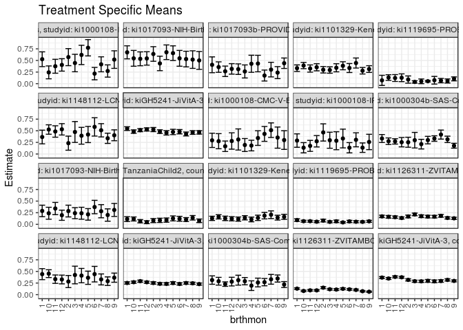

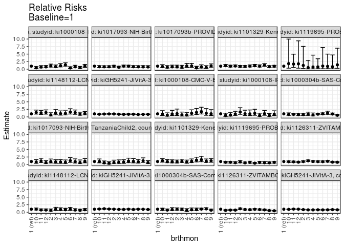

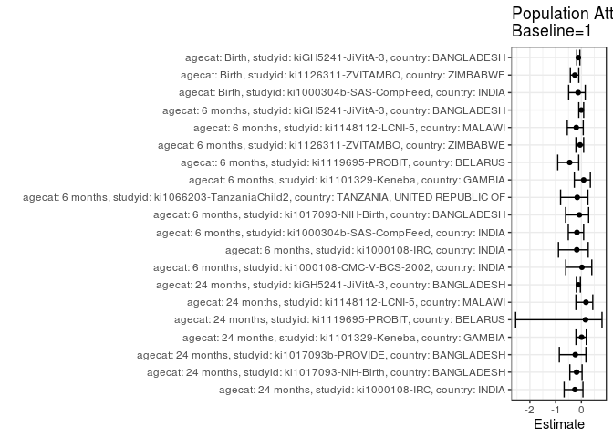

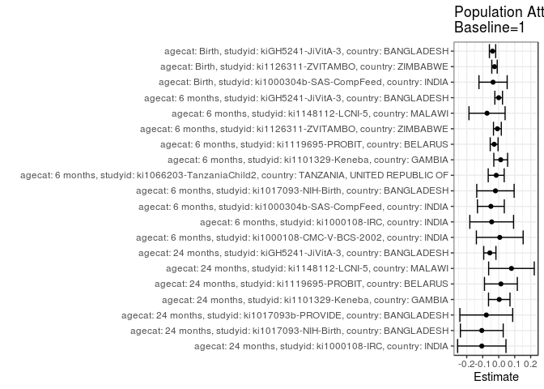

## Results Table

### Parameter: TSM

| agecat | studyid | country | intervention_level | baseline_level | estimate | ci_lower | ci_upper |
| --- | --- | --- | --- | --- | --- | --- | --- |
| Birth | ki1000304b-SAS-CompFeed | INDIA | 1 | NA | 0.3139535 | 0.2229282 | 0.4049787 |
| Birth | ki1000304b-SAS-CompFeed | INDIA | 2 | NA | 0.3116883 | 0.2055705 | 0.4178061 |
| Birth | ki1000304b-SAS-CompFeed | INDIA | 3 | NA | 0.2898551 | 0.2118669 | 0.3678433 |
| Birth | ki1000304b-SAS-CompFeed | INDIA | 4 | NA | 0.1935484 | 0.0898960 | 0.2972008 |
| Birth | ki1000304b-SAS-CompFeed | INDIA | 5 | NA | 0.2613636 | 0.1671305 | 0.3555968 |
| Birth | ki1000304b-SAS-CompFeed | INDIA | 6 | NA | 0.2692308 | 0.1908875 | 0.3475740 |
| Birth | ki1000304b-SAS-CompFeed | INDIA | 7 | NA | 0.3300000 | 0.2253702 | 0.4346298 |
| Birth | ki1000304b-SAS-CompFeed | INDIA | 8 | NA | 0.3472222 | 0.2710994 | 0.4233451 |
| Birth | ki1000304b-SAS-CompFeed | INDIA | 9 | NA | 0.2176871 | 0.1539752 | 0.2813989 |
| Birth | ki1000304b-SAS-CompFeed | INDIA | 10 | NA | 0.2887324 | 0.2055003 | 0.3719645 |
| Birth | ki1000304b-SAS-CompFeed | INDIA | 11 | NA | 0.2268908 | 0.1786385 | 0.2751430 |
| Birth | ki1000304b-SAS-CompFeed | INDIA | 12 | NA | 0.2807018 | 0.1874759 | 0.3739276 |
| Birth | ki1126311-ZVITAMBO | ZIMBABWE | 1 | NA | 0.1295607 | 0.1115996 | 0.1475217 |
| Birth | ki1126311-ZVITAMBO | ZIMBABWE | 2 | NA | 0.1501901 | 0.1286009 | 0.1717794 |
| Birth | ki1126311-ZVITAMBO | ZIMBABWE | 3 | NA | 0.1160791 | 0.0976689 | 0.1344893 |
| Birth | ki1126311-ZVITAMBO | ZIMBABWE | 4 | NA | 0.1098790 | 0.0904169 | 0.1293411 |
| Birth | ki1126311-ZVITAMBO | ZIMBABWE | 5 | NA | 0.1258604 | 0.1054741 | 0.1462467 |
| Birth | ki1126311-ZVITAMBO | ZIMBABWE | 6 | NA | 0.1143360 | 0.0958386 | 0.1328333 |
| Birth | ki1126311-ZVITAMBO | ZIMBABWE | 7 | NA | 0.1020408 | 0.0847397 | 0.1193420 |
| Birth | ki1126311-ZVITAMBO | ZIMBABWE | 8 | NA | 0.0739857 | 0.0595153 | 0.0884560 |
| Birth | ki1126311-ZVITAMBO | ZIMBABWE | 9 | NA | 0.0631255 | 0.0499003 | 0.0763507 |
| Birth | ki1126311-ZVITAMBO | ZIMBABWE | 10 | NA | 0.0797310 | 0.0632756 | 0.0961865 |
| Birth | ki1126311-ZVITAMBO | ZIMBABWE | 11 | NA | 0.0929839 | 0.0764345 | 0.1095334 |
| Birth | ki1126311-ZVITAMBO | ZIMBABWE | 12 | NA | 0.0921811 | 0.0759145 | 0.1084476 |
| Birth | kiGH5241-JiVitA-3 | BANGLADESH | 1 | NA | 0.3674727 | 0.3463152 | 0.3886302 |
| Birth | kiGH5241-JiVitA-3 | BANGLADESH | 2 | NA | 0.3179724 | 0.2945944 | 0.3413503 |
| Birth | kiGH5241-JiVitA-3 | BANGLADESH | 3 | NA | 0.2895639 | 0.2673656 | 0.3117623 |
| Birth | kiGH5241-JiVitA-3 | BANGLADESH | 4 | NA | 0.2874576 | 0.2634304 | 0.3114848 |
| Birth | kiGH5241-JiVitA-3 | BANGLADESH | 5 | NA | 0.2971216 | 0.2677711 | 0.3264722 |
| Birth | kiGH5241-JiVitA-3 | BANGLADESH | 6 | NA | 0.2866071 | 0.2573395 | 0.3158747 |

[output cut: 210 more lines]

### Parameter: E(Y)

| agecat | studyid | country | intervention_level | baseline_level | estimate | ci_lower | ci_upper |
| --- | --- | --- | --- | --- | --- | --- | --- |
| Birth | ki1000304b-SAS-CompFeed | INDIA | NA | NA | 0.2787540 | 0.2475949 | 0.3099131 |
| Birth | ki1126311-ZVITAMBO | ZIMBABWE | NA | NA | 0.1033514 | 0.0982859 | 0.1084168 |
| Birth | kiGH5241-JiVitA-3 | BANGLADESH | NA | NA | 0.3289690 | 0.3216017 | 0.3363364 |
| 6 months | ki1000108-CMC-V-BCS-2002 | INDIA | NA | NA | 0.3008130 | 0.2539566 | 0.3476694 |
| 6 months | ki1000108-IRC | INDIA | NA | NA | 0.2457002 | 0.2038248 | 0.2875757 |
| 6 months | ki1000304b-SAS-CompFeed | INDIA | NA | NA | 0.2844311 | 0.2666491 | 0.3022132 |
| 6 months | ki1017093-NIH-Birth | BANGLADESH | NA | NA | 0.2681564 | 0.2306532 | 0.3056597 |
| 6 months | ki1066203-TanzaniaChild2 | TANZANIA, UNITED REPUBLIC OF | NA | NA | 0.0970922 | 0.0842059 | 0.1099785 |
| 6 months | ki1101329-Keneba | GAMBIA | NA | NA | 0.1412159 | 0.1262788 | 0.1561530 |
| 6 months | ki1119695-PROBIT | BELARUS | NA | NA | 0.0626864 | 0.0488489 | 0.0765239 |
| 6 months | ki1126311-ZVITAMBO | ZIMBABWE | NA | NA | 0.1628792 | 0.1551057 | 0.1706527 |
| 6 months | ki1148112-LCNI-5 | MALAWI | NA | NA | 0.3682956 | 0.3356382 | 0.4009530 |
| 6 months | kiGH5241-JiVitA-3 | BANGLADESH | NA | NA | 0.2513830 | 0.2432594 | 0.2595066 |
| 24 months | ki1000108-IRC | INDIA | NA | NA | 0.4205379 | 0.3726382 | 0.4684376 |
| 24 months | ki1017093-NIH-Birth | BANGLADESH | NA | NA | 0.5687646 | 0.5218455 | 0.6156837 |
| 24 months | ki1017093b-PROVIDE | BANGLADESH | NA | NA | 0.3287197 | 0.2903909 | 0.3670485 |
| 24 months | ki1101329-Keneba | GAMBIA | NA | NA | 0.3368116 | 0.3145020 | 0.3591212 |
| 24 months | ki1119695-PROBIT | BELARUS | NA | NA | 0.0852540 | 0.0554439 | 0.1150642 |
| 24 months | ki1148112-LCNI-5 | MALAWI | NA | NA | 0.4455959 | 0.4050760 | 0.4861157 |
| 24 months | kiGH5241-JiVitA-3 | BANGLADESH | NA | NA | 0.4910797 | 0.4779658 | 0.5041936 |

### Parameter: RR

| agecat | studyid | country | intervention_level | baseline_level | estimate | ci_lower | ci_upper |
| --- | --- | --- | --- | --- | --- | --- | --- |
| Birth | ki1000304b-SAS-CompFeed | INDIA | 1 | 1 | 1.0000000 | 1.0000000 | 1.0000000 |
| Birth | ki1000304b-SAS-CompFeed | INDIA | 2 | 1 | 0.9927850 | 0.6798243 | 1.4498188 |
| Birth | ki1000304b-SAS-CompFeed | INDIA | 3 | 1 | 0.9232421 | 0.6185254 | 1.3780776 |
| Birth | ki1000304b-SAS-CompFeed | INDIA | 4 | 1 | 0.6164875 | 0.3235929 | 1.1744904 |
| Birth | ki1000304b-SAS-CompFeed | INDIA | 5 | 1 | 0.8324916 | 0.4852659 | 1.4281700 |
| Birth | ki1000304b-SAS-CompFeed | INDIA | 6 | 1 | 0.8575499 | 0.5283074 | 1.3919770 |
| Birth | ki1000304b-SAS-CompFeed | INDIA | 7 | 1 | 1.0511111 | 0.8087427 | 1.3661139 |
| Birth | ki1000304b-SAS-CompFeed | INDIA | 8 | 1 | 1.1059671 | 0.8204344 | 1.4908726 |
| Birth | ki1000304b-SAS-CompFeed | INDIA | 9 | 1 | 0.6933736 | 0.4727351 | 1.0169902 |
| Birth | ki1000304b-SAS-CompFeed | INDIA | 10 | 1 | 0.9196661 | 0.6282910 | 1.3461689 |
| Birth | ki1000304b-SAS-CompFeed | INDIA | 11 | 1 | 0.7226891 | 0.4815075 | 1.0846757 |
| Birth | ki1000304b-SAS-CompFeed | INDIA | 12 | 1 | 0.8940871 | 0.5315816 | 1.5037986 |
| Birth | ki1126311-ZVITAMBO | ZIMBABWE | 1 | 1 | 1.0000000 | 1.0000000 | 1.0000000 |
| Birth | ki1126311-ZVITAMBO | ZIMBABWE | 2 | 1 | 1.1592260 | 0.9493758 | 1.4154615 |
| Birth | ki1126311-ZVITAMBO | ZIMBABWE | 3 | 1 | 0.8959439 | 0.7257679 | 1.1060223 |
| Birth | ki1126311-ZVITAMBO | ZIMBABWE | 4 | 1 | 0.8480893 | 0.6772643 | 1.0620011 |
| Birth | ki1126311-ZVITAMBO | ZIMBABWE | 5 | 1 | 0.9714396 | 0.7849175 | 1.2022853 |
| Birth | ki1126311-ZVITAMBO | ZIMBABWE | 6 | 1 | 0.8824897 | 0.7131521 | 1.0920365 |
| Birth | ki1126311-ZVITAMBO | ZIMBABWE | 7 | 1 | 0.7875909 | 0.6326816 | 0.9804291 |
| Birth | ki1126311-ZVITAMBO | ZIMBABWE | 8 | 1 | 0.5710504 | 0.4493249 | 0.7257523 |
| Birth | ki1126311-ZVITAMBO | ZIMBABWE | 9 | 1 | 0.4872271 | 0.3789903 | 0.6263756 |
| Birth | ki1126311-ZVITAMBO | ZIMBABWE | 10 | 1 | 0.6153952 | 0.4799302 | 0.7890966 |
| Birth | ki1126311-ZVITAMBO | ZIMBABWE | 11 | 1 | 0.7176864 | 0.5727399 | 0.8993153 |
| Birth | ki1126311-ZVITAMBO | ZIMBABWE | 12 | 1 | 0.7114895 | 0.5684740 | 0.8904846 |
| Birth | kiGH5241-JiVitA-3 | BANGLADESH | 1 | 1 | 1.0000000 | 1.0000000 | 1.0000000 |
| Birth | kiGH5241-JiVitA-3 | BANGLADESH | 2 | 1 | 0.8652951 | 0.7841462 | 0.9548419 |
| Birth | kiGH5241-JiVitA-3 | BANGLADESH | 3 | 1 | 0.7879875 | 0.7163875 | 0.8667438 |
| Birth | kiGH5241-JiVitA-3 | BANGLADESH | 4 | 1 | 0.7822557 | 0.7067950 | 0.8657729 |
| Birth | kiGH5241-JiVitA-3 | BANGLADESH | 5 | 1 | 0.8085542 | 0.7211558 | 0.9065447 |
| Birth | kiGH5241-JiVitA-3 | BANGLADESH | 6 | 1 | 0.7799412 | 0.6950899 | 0.8751506 |

[output cut: 210 more lines]

### Parameter: PAR

| agecat | studyid | country | intervention_level | baseline_level | estimate | ci_lower | ci_upper |
| --- | --- | --- | --- | --- | --- | --- | --- |
| Birth | ki1000304b-SAS-CompFeed | INDIA | 1 | NA | -0.0351995 | -0.1234140 | 0.0530150 |
| Birth | ki1126311-ZVITAMBO | ZIMBABWE | 1 | NA | -0.0262093 | -0.0431152 | -0.0093035 |
| Birth | kiGH5241-JiVitA-3 | BANGLADESH | 1 | NA | -0.0385037 | -0.0582053 | -0.0188021 |
| 6 months | ki1000108-CMC-V-BCS-2002 | INDIA | 1 | NA | 0.0066954 | -0.1395296 | 0.1529203 |
| 6 months | ki1000108-IRC | INDIA | 1 | NA | -0.0437734 | -0.1805392 | 0.0929924 |
| 6 months | ki1000304b-SAS-CompFeed | INDIA | 1 | NA | -0.0489022 | -0.1327947 | 0.0349903 |
| 6 months | ki1017093-NIH-Birth | BANGLADESH | 1 | NA | -0.0203051 | -0.1371620 | 0.0965518 |
| 6 months | ki1066203-TanzaniaChild2 | TANZANIA, UNITED REPUBLIC OF | 1 | NA | -0.0155839 | -0.0655172 | 0.0343495 |
| 6 months | ki1101329-Keneba | GAMBIA | 1 | NA | 0.0126445 | -0.0304991 | 0.0557880 |
| 6 months | ki1119695-PROBIT | BELARUS | 1 | NA | -0.0285021 | -0.0530070 | -0.0039973 |
| 6 months | ki1126311-ZVITAMBO | ZIMBABWE | 1 | NA | -0.0082373 | -0.0326508 | 0.0161762 |
| 6 months | ki1148112-LCNI-5 | MALAWI | 1 | NA | -0.0728809 | -0.1857983 | 0.0400365 |
| 6 months | kiGH5241-JiVitA-3 | BANGLADESH | 1 | NA | -0.0001095 | -0.0240106 | 0.0237916 |
| 24 months | ki1000108-IRC | INDIA | 1 | NA | -0.1057779 | -0.2569873 | 0.0454315 |
| 24 months | ki1017093-NIH-Birth | BANGLADESH | 1 | NA | -0.1056540 | -0.2395269 | 0.0282188 |
| 24 months | ki1017093b-PROVIDE | BANGLADESH | 1 | NA | -0.0775303 | -0.2426478 | 0.0875872 |
| 24 months | ki1101329-Keneba | GAMBIA | 1 | NA | 0.0034783 | -0.0636220 | 0.0705785 |
| 24 months | ki1119695-PROBIT | BELARUS | 1 | NA | 0.0138255 | -0.0888873 | 0.1165382 |
| 24 months | ki1148112-LCNI-5 | MALAWI | 1 | NA | 0.0797422 | -0.0628519 | 0.2223363 |
| 24 months | kiGH5241-JiVitA-3 | BANGLADESH | 1 | NA | -0.0554668 | -0.0936215 | -0.0173122 |

### Parameter: PAF

| agecat | studyid | country | intervention_level | baseline_level | estimate | ci_lower | ci_upper |
| --- | --- | --- | --- | --- | --- | --- | --- |
| Birth | ki1000304b-SAS-CompFeed | INDIA | 1 | NA | -0.1262744 | -0.4936695 | 0.1507532 |
| Birth | ki1126311-ZVITAMBO | ZIMBABWE | 1 | NA | -0.2535945 | -0.4279399 | -0.1005360 |
| Birth | kiGH5241-JiVitA-3 | BANGLADESH | 1 | NA | -0.1170435 | -0.1785778 | -0.0587219 |
| 6 months | ki1000108-CMC-V-BCS-2002 | INDIA | 1 | NA | 0.0222576 | -0.6074578 | 0.4052843 |
| 6 months | ki1000108-IRC | INDIA | 1 | NA | -0.1781579 | -0.8893869 | 0.2653405 |
| 6 months | ki1000304b-SAS-CompFeed | INDIA | 1 | NA | -0.1719298 | -0.5079481 | 0.0892130 |
| 6 months | ki1017093-NIH-Birth | BANGLADESH | 1 | NA | -0.0757212 | -0.6129583 | 0.2825754 |
| 6 months | ki1066203-TanzaniaChild2 | TANZANIA, UNITED REPUBLIC OF | 1 | NA | -0.1605062 | -0.8071109 | 0.2547360 |
| 6 months | ki1101329-Keneba | GAMBIA | 1 | NA | 0.0895400 | -0.2733388 | 0.3490048 |
| 6 months | ki1119695-PROBIT | BELARUS | 1 | NA | -0.4546785 | -0.9179633 | -0.1033003 |
| 6 months | ki1126311-ZVITAMBO | ZIMBABWE | 1 | NA | -0.0505729 | -0.2116664 | 0.0891028 |
| 6 months | ki1148112-LCNI-5 | MALAWI | 1 | NA | -0.1978869 | -0.5475477 | 0.0727697 |
| 6 months | kiGH5241-JiVitA-3 | BANGLADESH | 1 | NA | -0.0004356 | -0.1001786 | 0.0902646 |
| 24 months | ki1000108-IRC | INDIA | 1 | NA | -0.2515300 | -0.6693066 | 0.0616899 |
| 24 months | ki1017093-NIH-Birth | BANGLADESH | 1 | NA | -0.1857606 | -0.4474142 | 0.0285931 |
| 24 months | ki1017093b-PROVIDE | BANGLADESH | 1 | NA | -0.2358553 | -0.8558346 | 0.1770074 |
| 24 months | ki1101329-Keneba | GAMBIA | 1 | NA | 0.0103270 | -0.2103626 | 0.1907775 |
| 24 months | ki1119695-PROBIT | BELARUS | 1 | NA | 0.1621678 | -2.5533822 | 0.8024522 |
| 24 months | ki1148112-LCNI-5 | MALAWI | 1 | NA | 0.1789563 | -0.2125668 | 0.4440614 |
| 24 months | kiGH5241-JiVitA-3 | BANGLADESH | 1 | NA | -0.1129488 | -0.1936247 | -0.0377256 |